# Salary Prediction

Corresponding with this notebook is a slide deck where you will need to update all the portions in red. Completing the notebook will provide all the results needed for the slides. **Correctly completing the slides is a required part of the project.**

- Introduction
- Part I - Descriptive Statistics
- Part II - Regression
- Part III - Interpret Results

### Introduction

Linear Regression is very commonly performed by data analysts and data scientists. For this project, you will be working to understand the results of a Linear Regression model associated with salaries. Your goal is to work through this notebook to understand what variables are related to salary, and how exactly they are related.

As a final check, assure you meet all the criteria on the rubric.

#### Part I - Descriptive Statistics

To get started, let's import our libraries.

```python
import pandas as pd
import numpy as np
import random
import matplotlib.pyplot as plt
import statsmodels.api as sm;

random.seed(0)
```

For each of the parts of question `1` notice links to [pandas documentation](https://pandas.pydata.org/) is provided to assist with answering the questions. Though there are other ways you could solve the questions, the documentation is provided to assist you with one fast way to find the answer to each question.

`1.a)` Now, read in the `salary_data.csv` data. Store it in `df`. Read in the dataset and take a look at the top few rows here. **This question is completed for you**:

```python
df = pd.read_csv('salary_data.csv')
df.head()
```

|  | Age | Gender | Education Level | Job Title | Years of Experience | Salary |
| --- | --- | --- | --- | --- | --- | --- |
| 0 | 32.0 | Male | Bachelor's | Software Engineer | 5.0 | 90000.0 |
| 1 | 28.0 | Female | Master's | Data Analyst | 3.0 | 65000.0 |
| 2 | 45.0 | Male | PhD | Senior Manager | 15.0 | 150000.0 |
| 3 | 36.0 | Female | Bachelor's | Sales Associate | 7.0 | 60000.0 |
| 4 | 52.0 | Male | Master's | Director | 20.0 | 200000.0 |

`b)` Use the below cell to find the number of rows in the dataset. [Helpful pandas link - `Dataframe.shape`](https://pandas.pydata.org/docs/reference/api/pandas.DataFrame.shape.html#pandas.DataFrame.shape)

```python
df.shape
```

```
(375, 6)
```

`c)` Do any of the rows have missing values? [Helpful pandas link - `Dataframe.isnull`](https://pandas.pydata.org/docs/reference/api/pandas.DataFrame.isnull.html) and [helpful pandas link - `Dataframe.sum`](https://pandas.pydata.org/docs/reference/api/pandas.DataFrame.sum.html)

If there are missing values, determine a method for dealing with them.

```python
df.isnull().sum()
```

```
Age                    2
Gender                 2
Education Level        2
Job Title              2
Years of Experience    2
Salary                 2
dtype: int64
```

```python
df.dropna(inplace=True)
print(df.isnull().sum())
```

```
Age                    0
Gender                 0
Education Level        0
Job Title              0
Years of Experience    0
Salary                 0
dtype: int64
```

```python
df.duplicated().sum()
```

```
49
```

```python
df.drop_duplicates(inplace=True)
df.duplicated().sum()
```

```
0
```

```python
df.shape
```

```
(324, 6)
```

`d)` How many employees are in each `Education Level`? Build a bar chart to show the count of employees in each level.

```python
df['Education Level'].value_counts()
```

```
Bachelor's    191
Master's       91
PhD            42
Name: Education Level, dtype: int64
```

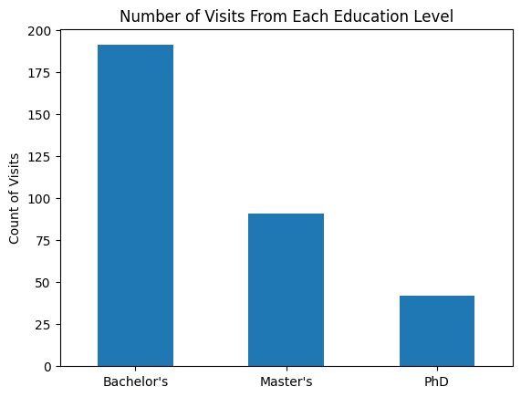

```python
# bar chart of results - this part is done for you
df['Education Level'].value_counts().plot(kind='bar');
plt.title('Number of Visits From Each Education Level');
plt.ylabel('Count of Visits');
plt.xticks(rotation=0)
plt.show();
```

`e)` What are the possible values for `Salary`? What does the distribution of `Salary` look like?

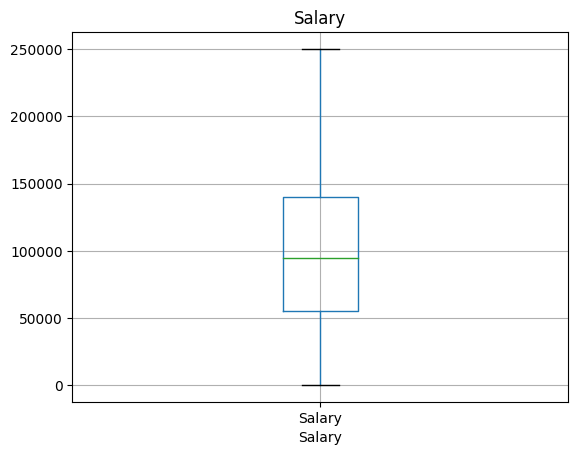

```python
df.boxplot(column='Salary')
plt.title('Salary')
plt.xlabel('Salary')
plt.show()
```

```python
df['Salary'].describe()
```

```
count       324.000000
mean      99985.648148
std       48652.271440
min         350.000000
25%       55000.000000
50%       95000.000000
75%      140000.000000
max      250000.000000
Name: Salary, dtype: float64
```

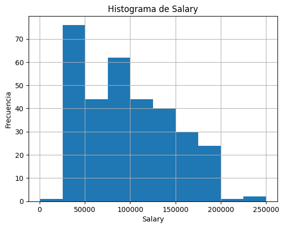

```python
df['Salary'].hist()
plt.title(f'Histograma de Salary')
plt.xlabel('Salary')
plt.ylabel('Frecuencia')
plt.show()
```

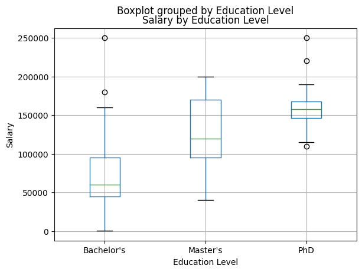

```python
df.boxplot(column='Salary', by='Education Level')
plt.title('Salary by Education Level')
plt.xlabel('Education Level')
plt.ylabel('Salary')
plt.show()
```

#### Part II - Regression

`1.` Now that you have had a chance to learn more about the dataset, let's look more at how different factors are related to `Salary`.

`a)` Consider average salary by gender, is there evidence that salaries are higher for one gender over the other? **This question is completed for you**

```python
df.groupby('Gender')['Salary'].mean()
```

```
Gender
Female     96136.363636
Male      103472.647059
Name: Salary, dtype: float64
```

`b)` Consider average salary by education level, is there evidence that salaries are higher for increased education?

```python
df.groupby('Education Level')['Salary'].mean()
```

```
Education Level
Bachelor's     73902.356021
Master's      127912.087912
PhD           158095.238095
Name: Salary, dtype: float64
```

`c)` Consider average salary by years of experience, is there evidence that salaries are associated with increased years of experience?

```python
df[['Years of Experience', 'Salary']].corr()
```

|  | Years of Experience | Salary |
| --- | --- | --- |
| Years of Experience | 1.000000 | 0.924455 |
| Salary | 0.924455 | 1.000000 |

The salary is high associated with increased years of experience!

`d)` To make use of Job Title column, let's create a bool flag based on word existence

List of words:

- Director
- Junior
- Senior
- Manager
- Analyst
- Engineer

**This question is completed for you**

```python
flag_words = ['director', 'junior', 'senior', 'manager', 'analyst', 'engineer']
df['Job Title'] = df['Job Title'].str.lower()

for word in flag_words:
    df['is_' + word] = df['Job Title'].str.contains(word)

df = df.drop('Job Title', axis=1)

for col in ['is_director', 'is_junior', 'is_senior', 'is_manager', 'is_analyst', 'is_engineer']:
    df[col] = df[col].astype(int)

df.head(5)
```

|  | Age | Gender | Education Level | Years of Experience | Salary | is_director | is_junior | is_senior | is_manager | is_analyst | is_engineer |
| --- | --- | --- | --- | --- | --- | --- | --- | --- | --- | --- | --- |
| 0 | 32.0 | Male | Bachelor's | 5.0 | 90000.0 | 0 | 0 | 0 | 0 | 0 | 1 |
| 1 | 28.0 | Female | Master's | 3.0 | 65000.0 | 0 | 0 | 0 | 0 | 1 | 0 |
| 2 | 45.0 | Male | PhD | 15.0 | 150000.0 | 0 | 0 | 1 | 1 | 0 | 0 |
| 3 | 36.0 | Female | Bachelor's | 7.0 | 60000.0 | 0 | 0 | 0 | 0 | 0 | 0 |
| 4 | 52.0 | Male | Master's | 20.0 | 200000.0 | 1 | 0 | 0 | 0 | 0 | 0 |

`e)` Create a flag for gender where 1 is if a person is male and 0 if the person is not.

```python
df[['is_Not','is_Male']] = pd.get_dummies(df['Gender'], dtype=int)
df = df.drop(columns=['Gender', 'is_Not'], axis=1)
df.head(5)
```

|  | Age | Education Level | Years of Experience | Salary | is_director | is_junior | is_senior | is_manager | is_analyst | is_engineer | is_Male |
| --- | --- | --- | --- | --- | --- | --- | --- | --- | --- | --- | --- |
| 0 | 32.0 | Bachelor's | 5.0 | 90000.0 | 0 | 0 | 0 | 0 | 0 | 1 | 1 |
| 1 | 28.0 | Master's | 3.0 | 65000.0 | 0 | 0 | 0 | 0 | 1 | 0 | 0 |
| 2 | 45.0 | PhD | 15.0 | 150000.0 | 0 | 0 | 1 | 1 | 0 | 0 | 1 |
| 3 | 36.0 | Bachelor's | 7.0 | 60000.0 | 0 | 0 | 0 | 0 | 0 | 0 | 0 |
| 4 | 52.0 | Master's | 20.0 | 200000.0 | 1 | 0 | 0 | 0 | 0 | 0 | 1 |

`f)` Use statsmodels to fit a linear model to predict salary using each of the features from `a-e`. These include:

- Gender
- Job TItle
- Years of Experience
- Education

```python
education_dummies = pd.get_dummies(df['Education Level'], prefix='Education', drop_first=True, dtype=int)
df = pd.concat([df, education_dummies], axis=1)
df.head()
```

|  | Age | Education Level | Years of Experience | Salary | is_director | is_junior | is_senior | is_manager | is_analyst | is_engineer | is_Male | Education_Master's | Education_PhD |
| --- | --- | --- | --- | --- | --- | --- | --- | --- | --- | --- | --- | --- | --- |
| 0 | 32.0 | Bachelor's | 5.0 | 90000.0 | 0 | 0 | 0 | 0 | 0 | 1 | 1 | 0 | 0 |
| 1 | 28.0 | Master's | 3.0 | 65000.0 | 0 | 0 | 0 | 0 | 1 | 0 | 0 | 1 | 0 |
| 2 | 45.0 | PhD | 15.0 | 150000.0 | 0 | 0 | 1 | 1 | 0 | 0 | 1 | 0 | 1 |
| 3 | 36.0 | Bachelor's | 7.0 | 60000.0 | 0 | 0 | 0 | 0 | 0 | 0 | 0 | 0 | 0 |
| 4 | 52.0 | Master's | 20.0 | 200000.0 | 1 | 0 | 0 | 0 | 0 | 0 | 1 | 1 | 0 |

```python
df = df.drop('is_director', axis=1)
df.head()
```

|  | Age | Education Level | Years of Experience | Salary | is_junior | is_senior | is_manager | is_analyst | is_engineer | is_Male | Education_Master's | Education_PhD |
| --- | --- | --- | --- | --- | --- | --- | --- | --- | --- | --- | --- | --- |
| 0 | 32.0 | Bachelor's | 5.0 | 90000.0 | 0 | 0 | 0 | 0 | 1 | 1 | 0 | 0 |
| 1 | 28.0 | Master's | 3.0 | 65000.0 | 0 | 0 | 0 | 1 | 0 | 0 | 1 | 0 |
| 2 | 45.0 | PhD | 15.0 | 150000.0 | 0 | 1 | 1 | 0 | 0 | 1 | 0 | 1 |
| 3 | 36.0 | Bachelor's | 7.0 | 60000.0 | 0 | 0 | 0 | 0 | 0 | 0 | 0 | 0 |
| 4 | 52.0 | Master's | 20.0 | 200000.0 | 0 | 0 | 0 | 0 | 0 | 1 | 1 | 0 |

```python
df['intercept'] = 1

X = df[['is_Male', 'Years of Experience', 'is_junior', 'is_senior', 'is_manager', 'is_analyst', 'is_engineer', 'Education_Master\'s', 'Education_PhD', 'intercept']]
y = df['Salary']

lm = sm.OLS(y, X)
results = lm.fit()
print(results.summary())
```

```
                            OLS Regression Results
==============================================================================
Dep. Variable:                 Salary   R-squared:                       0.896
Model:                            OLS   Adj. R-squared:                  0.893
Method:                 Least Squares   F-statistic:                     299.7
Date:                Tue, 15 Jul 2025   Prob (F-statistic):          2.18e-148
Time:                        02:12:03   Log-Likelihood:                -3589.8
No. Observations:                 324   AIC:                             7200.
Df Residuals:                     314   BIC:                             7237.
Df Model:                           9
Covariance Type:            nonrobust
=======================================================================================
                          coef    std err          t      P>|t|      [0.025      0.975]
---------------------------------------------------------------------------------------
is_Male              8652.8528   1819.677      4.755      0.000    5072.551    1.22e+04
Years of Experience  5640.4798    190.999     29.531      0.000    5264.680    6016.280
is_junior           -3609.6775   2855.816     -1.264      0.207   -9228.631    2009.277
is_senior            6458.6657   2151.545      3.002      0.003    2225.399    1.07e+04
is_manager            558.7344   2205.951      0.253      0.800   -3781.579    4899.048
is_analyst          -3586.7326   2607.052     -1.376      0.170   -8716.232    1542.767
is_engineer          -294.8188   4441.613     -0.066      0.947   -9033.904    8444.266
Education_Master's    1.78e+04   2322.145      7.665      0.000    1.32e+04    2.24e+04
Education_PhD        2.259e+04   3397.078      6.649      0.000    1.59e+04    2.93e+04
intercept            2.962e+04   2824.282     10.489      0.000    2.41e+04    3.52e+04
==============================================================================
Omnibus:                       30.807   Durbin-Watson:                   1.683
Prob(Omnibus):                  0.000   Jarque-Bera (JB):              112.747
Skew:                           0.282   Prob(JB):                     3.29e-25
Kurtosis:                       5.835   Cond. No.                         62.2
==============================================================================

Notes:
[1] Standard Errors assume that the covariance matrix of the errors is correctly specified.
```

### Part III - Interpret Results

`1.` Consider you are tasked with finding which features in your linear model are significantly related to salary. Were there any features that were not significantly related to salary in your first model? If not, remove those features and fit a new model. Only keep the features that were significant from the original model.

```python
# explain your answer and fit a new model with the reduced set of features here
#is_junior = 0.207 > p = 0.05
#is_manager 0.800  > p = 0.05
#is_analyst 0.170  > p = 0.05
#is_engineer 0.947 > p = 0.05

X = df[['is_Male', 'Years of Experience', 'is_senior', 'Education_Master\'s', 'Education_PhD', 'intercept']]

lm = sm.OLS(y, X)
results = lm.fit()
print(results.summary())
```

```
                            OLS Regression Results
==============================================================================
Dep. Variable:                 Salary   R-squared:                       0.894
Model:                            OLS   Adj. R-squared:                  0.893
Method:                 Least Squares   F-statistic:                     537.9
Date:                Tue, 15 Jul 2025   Prob (F-statistic):          9.12e-153
Time:                        02:12:03   Log-Likelihood:                -3592.0
No. Observations:                 324   AIC:                             7196.
Df Residuals:                     318   BIC:                             7219.
Df Model:                           5
Covariance Type:            nonrobust
=======================================================================================
                          coef    std err          t      P>|t|      [0.025      0.975]
---------------------------------------------------------------------------------------
is_Male              8382.5480   1778.387      4.714      0.000    4883.658    1.19e+04
Years of Experience  5803.5032    165.127     35.146      0.000    5478.624    6128.383
is_senior            7313.5528   1929.856      3.790      0.000    3516.654    1.11e+04
Education_Master's   1.814e+04   2272.966      7.980      0.000    1.37e+04    2.26e+04
Education_PhD        2.215e+04   3241.223      6.833      0.000    1.58e+04    2.85e+04
intercept            2.647e+04   1930.575     13.711      0.000    2.27e+04    3.03e+04
==============================================================================
Omnibus:                       31.029   Durbin-Watson:                   1.707
Prob(Omnibus):                  0.000   Jarque-Bera (JB):              114.811
Skew:                           0.281   Prob(JB):                     1.17e-25
Kurtosis:                       5.862   Cond. No.                         47.5
==============================================================================

Notes:
[1] Standard Errors assume that the covariance matrix of the errors is correctly specified.
```

`a)` With each additional year of experience, what is the expected change in salary? What is the 95% confidence interval of the change?

- With each additional `Year of Experience` the `Salary` increase by 5,803.50 dollars, holding all ese constant.
- We are confident that for each unit increase in `Year of Experience`, the median `Salary` will change by an amount between 5,478.62 and 6,128.38 dollars.

`b)` What is the expected difference in salary between someone with a senior title and someone with none of the other title indications?

- The difference of `is_Senior` oscillates 7,313.55 dollars of someone with none.

`c)` What is the expected difference in salary between someone with a PhD and an individual with no PhD nor master's degree? What is the 95% confidence interval of the change?

- The expected `Salary` for someone who has an `Education_PhD` is 22,150.00 dollars, holding all ese constant.
- We are confident that for each one with `Education_PhD`, the median `Salary` will change by an amount between 15,800.00 and 28,500.00 dollars.

`d)` If a male employee has 5 years of experience as a senior engineer with a bachelor's degree, what is the expected salary of the employee?

```python
intercept = 26470.00    # 1
Male = 8382.5480        # 1
Exp = 5803.5032         # 5
Senior = 7313.5528      # 1
engineer =  0           # 1
bachelor =  0           # 1

#[a = intercept + X(var.dep) + b(coef)]
salary_expected = intercept + (1 * Male) + (5 * Exp) + (1 * Senior) + (engineer * 1) + (bachelor * 1)
print(salary_expected)
```

```
71183.6168
```

- Therefore, the expected salary of a male employee with 5 years of experience as a senior engineer with a bachelor's degree is approximately $71,183.62

`e)` Imagine that the employee in question `d)` actually has a salary of $110,000, what would the residual be for this employee?

```python
residual = 110000 - salary_expected
print(residual)
```

```
38816.3832
```

- The residual for this employee is $38,816.38

`f)` How well do you think your model fits? What metrics or plots would you consider to understand if this model does a good job of predicting salary?

```python
from sklearn.metrics import mean_absolute_error, mean_squared_error
model = sm.OLS(y, X).fit()
y_pred = model.predict(X)

mae = mean_absolute_error(y, y_pred)
print(f"Mean Absolute Error (MAE): ${mae:,.2f}")

mse = mean_squared_error(y, y_pred)
print(f"Mean Squared Error (MSE): ${mse:,.2f}")

rmse = np.sqrt(mse)
print(f"Root Mean Squared Error (RMSE): ${rmse:,.2f}")
```

```
Mean Absolute Error (MAE): $11,221.89
Mean Squared Error (MSE): $249,499,614.60
Root Mean Squared Error (RMSE): $15,795.56
```

- **Adjusted R-squared:**  
  The Adjusted R-squared of 0.893 is also very high and close to R-squared, suggesting that the model, even with multiple predictors, maintains its explanatory power without being overly penalized for the number of features.

## Final Check!

Congratulations! You have reached the end of the salary prediction project! You should be very proud of all you have accomplished!

> **Tip**: Once you are satisfied with your work here, check over your notebook to make sure that it satisfies all the specifications mentioned in the rubric. You should also probably remove all of the "Hints" and "Tips" like this one so that the presentation is as polished as possible.

## Submission

Please follow the directions in the classroom to submit this notebook, as well as your completed slides.